# Bike Sharing System Model for BoomBikes

```
- Linear Regression Method to find which variables are significant in predicting the demand for shared bikes.
- Perform test prediction and find how well those variables describe the bike demands
```

```python
#importing libraries

import numpy as np
import pandas as pd
import matplotlib.pyplot as plt
import seaborn as sns
import sklearn
from sklearn.model_selection import train_test_split
from sklearn.preprocessing import MinMaxScaler
import statsmodels.api as sm
from statsmodels.stats.outliers_influence import variance_inflation_factor
from sklearn.metrics import r2_score

import warnings
warnings.filterwarnings('ignore')
```

## Analysing the Data

```python
#read the data
df = pd.read_csv("day.csv")
df.head()
```

|  | instant | dteday | season | yr | mnth | holiday | weekday | workingday | weathersit | temp | atemp | hum | windspeed | casual | registered | cnt |
| --- | --- | --- | --- | --- | --- | --- | --- | --- | --- | --- | --- | --- | --- | --- | --- | --- |
| 0 | 1 | 01-01-2018 | 1 | 0 | 1 | 0 | 6 | 0 | 2 | 14.110847 | 18.18125 | 80.5833 | 10.749882 | 331 | 654 | 985 |
| 1 | 2 | 02-01-2018 | 1 | 0 | 1 | 0 | 0 | 0 | 2 | 14.902598 | 17.68695 | 69.6087 | 16.652113 | 131 | 670 | 801 |
| 2 | 3 | 03-01-2018 | 1 | 0 | 1 | 0 | 1 | 1 | 1 | 8.050924 | 9.47025 | 43.7273 | 16.636703 | 120 | 1229 | 1349 |
| 3 | 4 | 04-01-2018 | 1 | 0 | 1 | 0 | 2 | 1 | 1 | 8.200000 | 10.60610 | 59.0435 | 10.739832 | 108 | 1454 | 1562 |
| 4 | 5 | 05-01-2018 | 1 | 0 | 1 | 0 | 3 | 1 | 1 | 9.305237 | 11.46350 | 43.6957 | 12.522300 | 82 | 1518 | 1600 |

```python
# Check the  information and Dtypes
df.info()
```

```
<class 'pandas.core.frame.DataFrame'>
RangeIndex: 730 entries, 0 to 729
Data columns (total 16 columns):
 #   Column      Non-Null Count  Dtype
---  ------      --------------  -----
 0   instant     730 non-null    int64
 1   dteday      730 non-null    object
 2   season      730 non-null    int64
 3   yr          730 non-null    int64
 4   mnth        730 non-null    int64
 5   holiday     730 non-null    int64
 6   weekday     730 non-null    int64
 7   workingday  730 non-null    int64
 8   weathersit  730 non-null    int64
 9   temp        730 non-null    float64
 10  atemp       730 non-null    float64
 11  hum         730 non-null    float64
 12  windspeed   730 non-null    float64
 13  casual      730 non-null    int64
 14  registered  730 non-null    int64
 15  cnt         730 non-null    int64
dtypes: float64(4), int64(11), object(1)
memory usage: 91.4+ KB
```

```python
print(df.shape)
df.describe()
```

```
(730, 16)
```

|  | instant | season | yr | mnth | holiday | weekday | workingday | weathersit | temp | atemp | hum | windspeed | casual | registered | cnt |
| --- | --- | --- | --- | --- | --- | --- | --- | --- | --- | --- | --- | --- | --- | --- | --- |
| count | 730.000000 | 730.000000 | 730.000000 | 730.000000 | 730.000000 | 730.000000 | 730.000000 | 730.000000 | 730.000000 | 730.000000 | 730.000000 | 730.000000 | 730.000000 | 730.000000 | 730.000000 |
| mean | 365.500000 | 2.498630 | 0.500000 | 6.526027 | 0.028767 | 2.997260 | 0.683562 | 1.394521 | 20.319259 | 23.726322 | 62.765175 | 12.763620 | 849.249315 | 3658.757534 | 4508.006849 |
| std | 210.877136 | 1.110184 | 0.500343 | 3.450215 | 0.167266 | 2.006161 | 0.465405 | 0.544807 | 7.506729 | 8.150308 | 14.237589 | 5.195841 | 686.479875 | 1559.758728 | 1936.011647 |
| min | 1.000000 | 1.000000 | 0.000000 | 1.000000 | 0.000000 | 0.000000 | 0.000000 | 1.000000 | 2.424346 | 3.953480 | 0.000000 | 1.500244 | 2.000000 | 20.000000 | 22.000000 |
| 25% | 183.250000 | 2.000000 | 0.000000 | 4.000000 | 0.000000 | 1.000000 | 0.000000 | 1.000000 | 13.811885 | 16.889713 | 52.000000 | 9.041650 | 316.250000 | 2502.250000 | 3169.750000 |
| 50% | 365.500000 | 3.000000 | 0.500000 | 7.000000 | 0.000000 | 3.000000 | 1.000000 | 1.000000 | 20.465826 | 24.368225 | 62.625000 | 12.125325 | 717.000000 | 3664.500000 | 4548.500000 |
| 75% | 547.750000 | 3.000000 | 1.000000 | 10.000000 | 0.000000 | 5.000000 | 1.000000 | 2.000000 | 26.880615 | 30.445775 | 72.989575 | 15.625589 | 1096.500000 | 4783.250000 | 5966.000000 |
| max | 730.000000 | 4.000000 | 1.000000 | 12.000000 | 1.000000 | 6.000000 | 1.000000 | 3.000000 | 35.328347 | 42.044800 | 97.250000 | 34.000021 | 3410.000000 | 6946.000000 | 8714.000000 |

# Check for NULL and Incorrect values

```python
100*(df.isnull().sum()/len(df)).sort_values(ascending=True)
```

```
instant       0.0
dteday        0.0
season        0.0
yr            0.0
mnth          0.0
holiday       0.0
weekday       0.0
workingday    0.0
weathersit    0.0
temp          0.0
atemp         0.0
hum           0.0
windspeed     0.0
casual        0.0
registered    0.0
cnt           0.0
dtype: float64
```

###### We see 0 null value % , to verify we list count of null values

```python
df.isnull().sum()
```

```
instant       0
dteday        0
season        0
yr            0
mnth          0
holiday       0
weekday       0
workingday    0
weathersit    0
temp          0
atemp         0
hum           0
windspeed     0
casual        0
registered    0
cnt           0
dtype: int64
```

```python
# No Null values , we check for duplicates

df_test = df.copy()

# Checking for duplicates and dropping the entire duplicate row if any
df_test.drop_duplicates(subset=None, inplace=True)

print(df_test.shape)
print(df.shape)
```

```
(730, 16)
(730, 16)
```

#### Clean Unneccessary Data Columns , Correct the dType format and disintegrate categorical variables to numerical variables

```python
# We see above Date is datetype which might create issues in buulding models
#so converting date to Pandas datetime format and finding the days elapsed to use as numerical

df['dteday'] = pd.to_datetime(df['dteday'])
print(df['dteday'].min())
```

```
2018-01-01 00:00:00
```

```python
# Deriving "days since the show started"
from datetime import date

d0 = date(2018, 1, 1)
delta = []
for d in df.dteday:
    delta.append(d.date() - d0)
df['day']= delta
df.head()
```

|  | instant | dteday | season | yr | mnth | holiday | weekday | workingday | weathersit | temp | atemp | hum | windspeed | casual | registered | cnt | day |
| --- | --- | --- | --- | --- | --- | --- | --- | --- | --- | --- | --- | --- | --- | --- | --- | --- | --- |
| 0 | 1 | 2018-01-01 | 1 | 0 | 1 | 0 | 6 | 0 | 2 | 14.110847 | 18.18125 | 80.5833 | 10.749882 | 331 | 654 | 985 | 0 days |
| 1 | 2 | 2018-02-01 | 1 | 0 | 1 | 0 | 0 | 0 | 2 | 14.902598 | 17.68695 | 69.6087 | 16.652113 | 131 | 670 | 801 | 31 days |
| 2 | 3 | 2018-03-01 | 1 | 0 | 1 | 0 | 1 | 1 | 1 | 8.050924 | 9.47025 | 43.7273 | 16.636703 | 120 | 1229 | 1349 | 59 days |
| 3 | 4 | 2018-04-01 | 1 | 0 | 1 | 0 | 2 | 1 | 1 | 8.200000 | 10.60610 | 59.0435 | 10.739832 | 108 | 1454 | 1562 | 90 days |
| 4 | 5 | 2018-05-01 | 1 | 0 | 1 | 0 | 3 | 1 | 1 | 9.305237 | 11.46350 | 43.6957 | 12.522300 | 82 | 1518 | 1600 | 120 days |

```python
# Cleaning days at end of day
df['day'] = df['day'].astype(str)
df['day'] = df['day'].map(lambda x: x[0:2])
df['day'] = df['day'].astype(int)
df.head()
```

|  | instant | dteday | season | yr | mnth | holiday | weekday | workingday | weathersit | temp | atemp | hum | windspeed | casual | registered | cnt | day |
| --- | --- | --- | --- | --- | --- | --- | --- | --- | --- | --- | --- | --- | --- | --- | --- | --- | --- |
| 0 | 1 | 2018-01-01 | 1 | 0 | 1 | 0 | 6 | 0 | 2 | 14.110847 | 18.18125 | 80.5833 | 10.749882 | 331 | 654 | 985 | 0 |
| 1 | 2 | 2018-02-01 | 1 | 0 | 1 | 0 | 0 | 0 | 2 | 14.902598 | 17.68695 | 69.6087 | 16.652113 | 131 | 670 | 801 | 31 |
| 2 | 3 | 2018-03-01 | 1 | 0 | 1 | 0 | 1 | 1 | 1 | 8.050924 | 9.47025 | 43.7273 | 16.636703 | 120 | 1229 | 1349 | 59 |
| 3 | 4 | 2018-04-01 | 1 | 0 | 1 | 0 | 2 | 1 | 1 | 8.200000 | 10.60610 | 59.0435 | 10.739832 | 108 | 1454 | 1562 | 90 |
| 4 | 5 | 2018-05-01 | 1 | 0 | 1 | 0 | 3 | 1 | 1 | 9.305237 | 11.46350 | 43.6957 | 12.522300 | 82 | 1518 | 1600 | 12 |

```python
#Converting categorical season variables
varlist = ['season']

def seasonFunc(x):
    return x.map({1:'spring', 2:'summer', 3:'fall', 4:'winter'})

season_group = df[varlist]
season_group = season_group.apply(seasonFunc)

df['season'] = season_group
```

```python
#Converting categorical weathersit variables
varlist = ['weathersit']

def weathersitFunc(x):
    return x.map({1:'Good_weathr', 2:'Avg_weathr', 3:'Bad_weathr', 4:'VeryBad_weathr'})

weather_group = df[varlist]
weather_group = weather_group.apply(weathersitFunc)

df['weathersit'] = weather_group
```

```python
#Converting categorical  weekday variables
varlist = ['weekday']

def weekdayFunc(x):
    return x.map({0:'Sunday', 1:'Monday', 2:'Tuesday', 3:'Wednesday',4:'Thrusday', 5:'Friday', 6:'Saturday'})

weekday_group = df[varlist]
weekday_group = weekday_group.apply(weekdayFunc)

df['weekday'] = weekday_group
```

```python
#Converting categorical mnth variables
varlist = ['mnth']

def mthFunc(x):
    return x.map({1:'January', 2:'February', 3:'March',4:'April', 5:'May', 6:'June',7:'July', 8:'Aug', 9:'Sept',10:'Oct', 11:'Nov', 12:'Dec'})

mnth_group = df[varlist]
mnth_group = mnth_group.apply(mthFunc)

df['mnth'] = mnth_group
df.head()
```

|  | instant | dteday | season | yr | mnth | holiday | weekday | workingday | weathersit | temp | atemp | hum | windspeed | casual | registered | cnt | day |
| --- | --- | --- | --- | --- | --- | --- | --- | --- | --- | --- | --- | --- | --- | --- | --- | --- | --- |
| 0 | 1 | 2018-01-01 | spring | 0 | January | 0 | Saturday | 0 | Avg_weathr | 14.110847 | 18.18125 | 80.5833 | 10.749882 | 331 | 654 | 985 | 0 |
| 1 | 2 | 2018-02-01 | spring | 0 | January | 0 | Sunday | 0 | Avg_weathr | 14.902598 | 17.68695 | 69.6087 | 16.652113 | 131 | 670 | 801 | 31 |
| 2 | 3 | 2018-03-01 | spring | 0 | January | 0 | Monday | 1 | Good_weathr | 8.050924 | 9.47025 | 43.7273 | 16.636703 | 120 | 1229 | 1349 | 59 |
| 3 | 4 | 2018-04-01 | spring | 0 | January | 0 | Tuesday | 1 | Good_weathr | 8.200000 | 10.60610 | 59.0435 | 10.739832 | 108 | 1454 | 1562 | 90 |
| 4 | 5 | 2018-05-01 | spring | 0 | January | 0 | Wednesday | 1 | Good_weathr | 9.305237 | 11.46350 | 43.6957 | 12.522300 | 82 | 1518 | 1600 | 12 |

### Categorical Variables Analysis

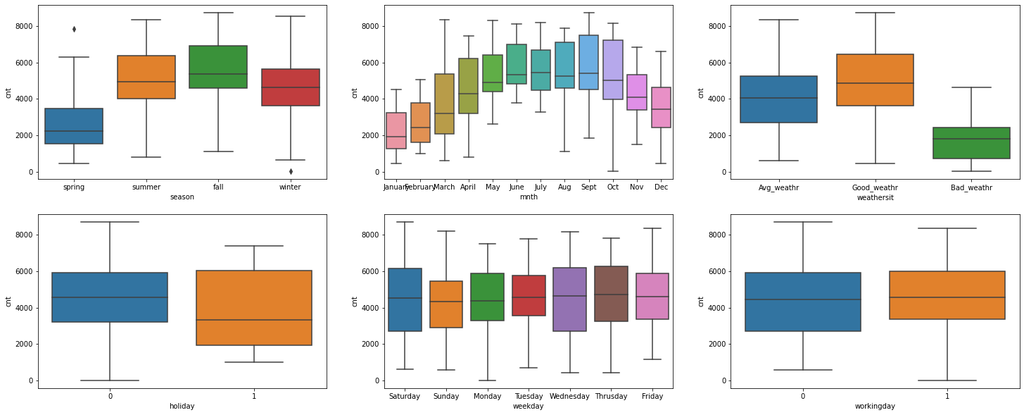

```python
# Build boxplot of all categorical variables (before creating dummies) againt the target variable 'cnt'
# to see how each of the predictor variable stackup against the target variable.

plt.figure(figsize=(25, 10))
plt.subplot(2,3,1)
sns.boxplot(x = 'season', y = 'cnt', data = df)
plt.subplot(2,3,2)
sns.boxplot(x = 'mnth', y = 'cnt', data = df)
plt.subplot(2,3,3)
sns.boxplot(x = 'weathersit', y = 'cnt', data = df)
plt.subplot(2,3,4)
sns.boxplot(x = 'holiday', y = 'cnt', data = df)
plt.subplot(2,3,5)
sns.boxplot(x = 'weekday', y = 'cnt', data = df)
plt.subplot(2,3,6)
sns.boxplot(x = 'workingday', y = 'cnt', data = df)
plt.show()
```

```python
# 1) Create Dummy variable for categorical variables and
# Drop original variable  and Drop first dummy variable for each set of dummies created.

df = pd.get_dummies(df,drop_first=True)
df.info()
```

```
<class 'pandas.core.frame.DataFrame'>
RangeIndex: 730 entries, 0 to 729
Data columns (total 35 columns):
 #   Column                  Non-Null Count  Dtype
---  ------                  --------------  -----
 0   instant                 730 non-null    int64
 1   dteday                  730 non-null    datetime64[ns]
 2   yr                      730 non-null    int64
 3   holiday                 730 non-null    int64
 4   workingday              730 non-null    int64
 5   temp                    730 non-null    float64
 6   atemp                   730 non-null    float64
 7   hum                     730 non-null    float64
 8   windspeed               730 non-null    float64
 9   casual                  730 non-null    int64
```

[output cut: 27 more lines]

```python
#Drop unnecessary column instant which is just a serial number
df = df.drop(["instant"],axis=1)
```

```python
# Drop casual and registered variable as they add up to cnt variable
df = df.drop(["casual"],axis=1)
df = df.drop(["registered"],axis=1)
```

```python
# already we have got days from dte days . Also we have yr and month so we dont need dtedays
df = df.drop(["dteday"],axis=1)
```

## Splitting Train and Test Data set

```python
df_train,df_test=train_test_split(df,train_size=0.7,random_state=100)
print(df_test.shape)
print(df_train.shape)
```

```
(220, 31)
(510, 31)
```

# Exploratory Data Analysis on Train Data

```python
df_train.info()
```

```
<class 'pandas.core.frame.DataFrame'>
Int64Index: 510 entries, 576 to 520
Data columns (total 31 columns):
 #   Column                  Non-Null Count  Dtype
---  ------                  --------------  -----
 0   yr                      510 non-null    int64
 1   holiday                 510 non-null    int64
 2   workingday              510 non-null    int64
 3   temp                    510 non-null    float64
 4   atemp                   510 non-null    float64
 5   hum                     510 non-null    float64
 6   windspeed               510 non-null    float64
 7   cnt                     510 non-null    int64
 8   day                     510 non-null    int64
 9   season_spring           510 non-null    uint8
```

[output cut: 23 more lines]

### Numerical Variable analysis .

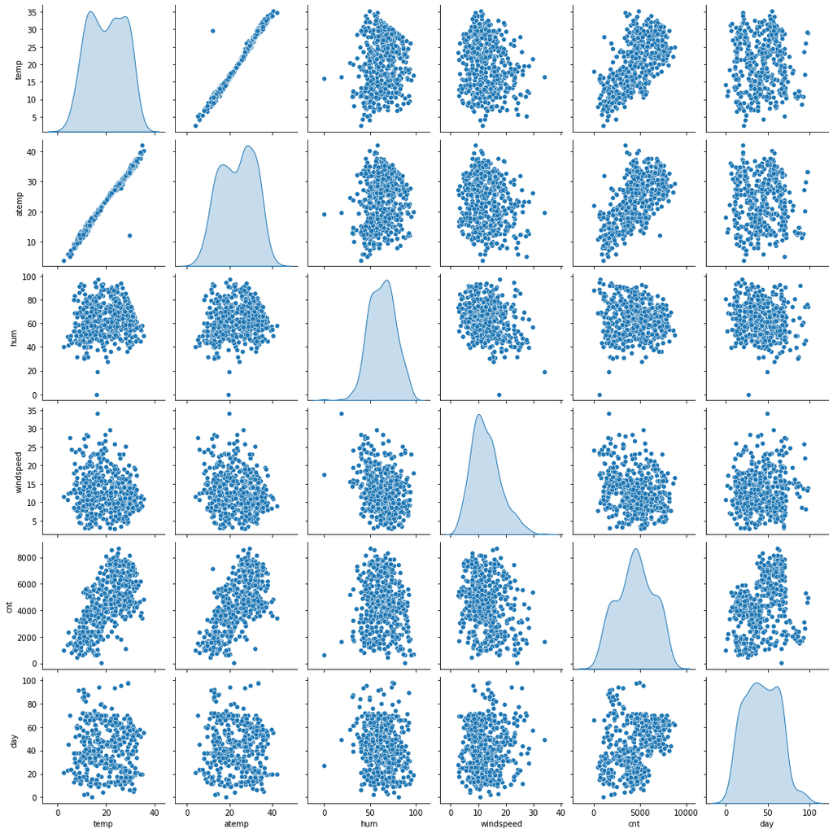

```python
# Create a new dataframe of only numeric variables and find a pairplot to see linear variables :

df_num=df_train[[ 'temp', 'atemp', 'hum', 'windspeed','cnt','day']]
sns.pairplot(df_num, diag_kind='kde')
plt.show()
```

###### We see temp and atemp has linear relation above

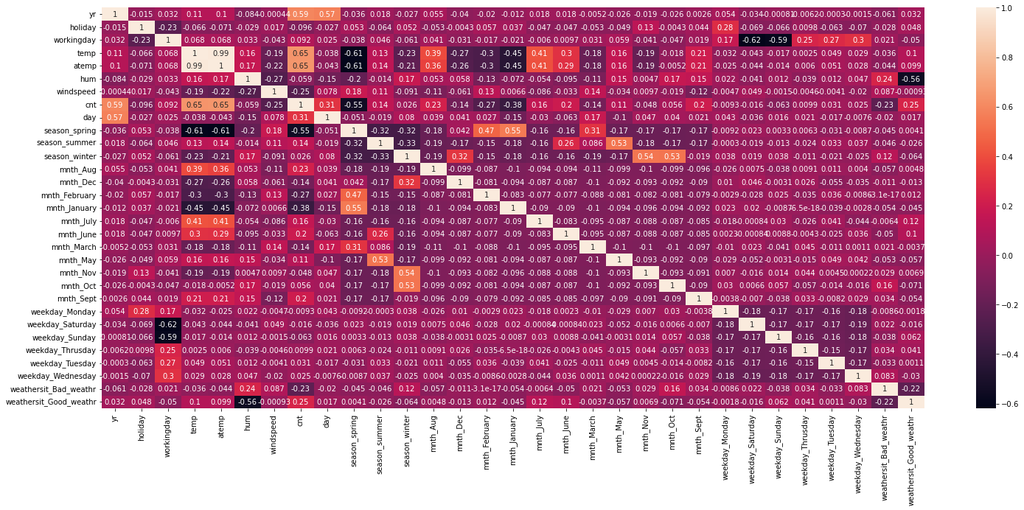

```python
#see the correlation
plt.figure(figsize = (25,10))
sns.heatmap(df_train.corr(),annot = True)
plt.show()
```

##### We see above year and temp are highly corelated to cnt . Also many multicollinear variables exists

## Rescaling the variables for faster gradient descent - Min Max Scaling

```python
#Instantiate an object

scaler= MinMaxScaler()

#Create a list of numeric vars
num_vars = ['temp','atemp','hum','windspeed','cnt','day']

#Fit Data  - learns Min and Max , trnasform Normalises the data by applying the formulae
df_train[num_vars]=scaler.fit_transform(df_train[num_vars])
df_train.head()
```

|  | yr | holiday | workingday | temp | atemp | hum | windspeed | cnt | day | season_spring | ... | mnth_Oct | mnth_Sept | weekday_Monday | weekday_Saturday | weekday_Sunday | weekday_Thrusday | weekday_Tuesday | weekday_Wednesday | weathersit_Bad_weathr | weathersit_Good_weathr |
| --- | --- | --- | --- | --- | --- | --- | --- | --- | --- | --- | --- | --- | --- | --- | --- | --- | --- | --- | --- | --- | --- |
| 576 | 1 | 0 | 1 | 0.815169 | 0.766351 | 0.725633 | 0.264686 | 0.827658 | 0.581633 | 0 | ... | 0 | 0 | 0 | 0 | 0 | 0 | 1 | 0 | 0 | 1 |
| 426 | 1 | 0 | 0 | 0.442393 | 0.438975 | 0.640189 | 0.255342 | 0.465255 | 0.428571 | 1 | ... | 0 | 0 | 0 | 1 | 0 | 0 | 0 | 0 | 0 | 0 |
| 728 | 1 | 0 | 0 | 0.245101 | 0.200348 | 0.498067 | 0.663106 | 0.204096 | 0.734694 | 1 | ... | 0 | 0 | 0 | 0 | 1 | 0 | 0 | 0 | 0 | 1 |
| 482 | 1 | 0 | 0 | 0.395666 | 0.391735 | 0.504508 | 0.188475 | 0.482973 | 0.489796 | 0 | ... | 0 | 0 | 0 | 1 | 0 | 0 | 0 | 0 | 0 | 0 |
| 111 | 0 | 0 | 1 | 0.345824 | 0.318819 | 0.751824 | 0.380981 | 0.191095 | 0.112245 | 0 | ... | 0 | 0 | 0 | 0 | 0 | 0 | 0 | 0 | 0 | 0 |

5 rows × 31 columns

## Variable Selection using RFE

```python
from sklearn.feature_selection import RFE
from sklearn.linear_model import LinearRegression
```

```python
# X_train, y_train
y_train = df_train.pop('cnt')
X_train = df_train
```

```python
lm = LinearRegression()
lm.fit(X_train,y_train)

rfe = RFE(lm,15)
rfe=rfe.fit(X_train,y_train)
```

```python
list(zip(X_train.columns,rfe.support_,rfe.ranking_))
```

```
[('yr', True, 1),
 ('holiday', True, 1),
 ('workingday', True, 1),
 ('temp', True, 1),
 ('atemp', False, 5),
 ('hum', True, 1),
 ('windspeed', True, 1),
 ('day', False, 7),
 ('season_spring', True, 1),
 ('season_summer', True, 1),
 ('season_winter', True, 1),
 ('mnth_Aug', False, 8),
 ('mnth_Dec', False, 3),
 ('mnth_February', False, 4),
 ('mnth_January', True, 1),
 ('mnth_July', True, 1),
 ('mnth_June', False, 13),
 ('mnth_March', False, 14),
 ('mnth_May', False, 6),
 ('mnth_Nov', False, 2),
 ('mnth_Oct', False, 12),
 ('mnth_Sept', True, 1),
 ('weekday_Monday', False, 10),
 ('weekday_Saturday', True, 1),
 ('weekday_Sunday', False, 9),
 ('weekday_Thrusday', False, 15),
 ('weekday_Tuesday', False, 11),
 ('weekday_Wednesday', False, 16),
 ('weathersit_Bad_weathr', True, 1),
 ('weathersit_Good_weathr', True, 1)]
```

```python
#Selected columns
col = X_train.columns[rfe.support_]
col
```

```
Index(['yr', 'holiday', 'workingday', 'temp', 'hum', 'windspeed',
       'season_spring', 'season_summer', 'season_winter', 'mnth_January',
       'mnth_July', 'mnth_Sept', 'weekday_Saturday', 'weathersit_Bad_weathr',
       'weathersit_Good_weathr'],
      dtype='object')
```

```python
X_train_rfe = X_train[col]
```

```python
#Non selected
X_train.columns[~rfe.support_]
```

```
Index(['atemp', 'day', 'mnth_Aug', 'mnth_Dec', 'mnth_February', 'mnth_June',
       'mnth_March', 'mnth_May', 'mnth_Nov', 'mnth_Oct', 'weekday_Monday',
       'weekday_Sunday', 'weekday_Thrusday', 'weekday_Tuesday',
       'weekday_Wednesday'],
      dtype='object')
```

## Start Building Models . We target to fine tune and get best over iterations by watching p-value, cofficient,vif and buisness significance

## Linear Regression Model 1

```python
X_train_sm_1 = sm.add_constant(X_train_rfe)
lr_1 = sm.OLS(y_train,X_train_sm_1)
lr_model_1 = lr_1.fit()
lr_model_1.params
lr_model_1.summary()
```

OLS Regression Results

| Dep. Variable: | cnt | R-squared: | 0.848 |
| --- | --- | --- | --- |
| Model: | OLS | Adj. R-squared: | 0.844 |
| Method: | Least Squares | F-statistic: | 184.0 |
| Date: | Wed, 13 Apr 2022 | Prob (F-statistic): | 4.22e-191 |
| Time: | 18:06:40 | Log-Likelihood: | 519.65 |
| No. Observations: | 510 | AIC: | -1007. |
| Df Residuals: | 494 | BIC: | -939.5 |
| Df Model: | 15 |  |  |
| Covariance Type: | nonrobust |  |  |

|  | coef | std err | t | P>\|t\| | [0.025 | 0.975] |
| --- | --- | --- | --- | --- | --- | --- |
| const | 0.1956 | 0.040 | 4.932 | 0.000 | 0.118 | 0.273 |
| yr | 0.2305 | 0.008 | 28.795 | 0.000 | 0.215 | 0.246 |
| holiday | -0.0582 | 0.027 | -2.164 | 0.031 | -0.111 | -0.005 |
| workingday | 0.0433 | 0.012 | 3.762 | 0.000 | 0.021 | 0.066 |
| temp | 0.5096 | 0.034 | 14.837 | 0.000 | 0.442 | 0.577 |
| hum | -0.1563 | 0.037 | -4.188 | 0.000 | -0.230 | -0.083 |
| windspeed | -0.1863 | 0.025 | -7.310 | 0.000 | -0.236 | -0.136 |
| season_spring | -0.0509 | 0.021 | -2.464 | 0.014 | -0.091 | -0.010 |
| season_summer | 0.0508 | 0.015 | 3.423 | 0.001 | 0.022 | 0.080 |
| season_winter | 0.0933 | 0.017 | 5.403 | 0.000 | 0.059 | 0.127 |
| mnth_January | -0.0345 | 0.017 | -1.989 | 0.047 | -0.069 | -0.000 |
| mnth_July | -0.0529 | 0.018 | -2.931 | 0.004 | -0.088 | -0.017 |
| mnth_Sept | 0.0814 | 0.016 | 4.945 | 0.000 | 0.049 | 0.114 |
| weekday_Saturday | 0.0536 | 0.014 | 3.694 | 0.000 | 0.025 | 0.082 |
| weathersit_Bad_weathr | -0.1911 | 0.025 | -7.755 | 0.000 | -0.240 | -0.143 |
| weathersit_Good_weathr | 0.0563 | 0.010 | 5.439 | 0.000 | 0.036 | 0.077 |

| Omnibus: | 66.260 | Durbin-Watson: | 2.080 |
| --- | --- | --- | --- |
| Prob(Omnibus): | 0.000 | Jarque-Bera (JB): | 159.826 |
| Skew: | -0.678 | Prob(JB): | 1.97e-35 |
| Kurtosis: | 5.383 | Cond. No. | 24.0 |

Notes:  
[1] Standard Errors assume that the covariance matrix of the errors is correctly specified.

```python
vif = pd.DataFrame()
vif['Features'] = X_train_rfe.columns
vif['VIF'] = [variance_inflation_factor(X_train_rfe.values,i) for i in range(X_train_rfe.shape[1])]
vif['VIF'] = round(vif['VIF'],2)
vif=vif.sort_values(by="VIF",ascending=False)
vif
```

|  | Features | VIF |
| --- | --- | --- |
| 4 | hum | 24.61 |
| 3 | temp | 20.45 |
| 2 | workingday | 5.32 |
| 6 | season_spring | 5.05 |
| 5 | windspeed | 4.72 |
| 8 | season_winter | 3.81 |
| 14 | weathersit_Good_weathr | 3.45 |
| 7 | season_summer | 2.99 |
| 0 | yr | 2.09 |
| 12 | weekday_Saturday | 1.98 |
| 9 | mnth_January | 1.68 |
| 10 | mnth_July | 1.60 |
| 11 | mnth_Sept | 1.39 |
| 1 | holiday | 1.18 |
| 13 | weathersit_Bad_weathr | 1.15 |

## Model 2 Building

```python
#We have contendors from having highest VIF value or p-value month_jan/holiday but we think month_jan is more significance to probelm desc than humudity . So we choose humidity and monitor for others
X_train_rfe = X_train_rfe.drop(["hum"], axis = 1)
```

```python
X_train_sm_2 = sm.add_constant(X_train_rfe)
lr_2 = sm.OLS(y_train,X_train_sm_2)
lr_model_2 = lr_2.fit()
lr_model_2.params
lr_model_2.summary()
```

OLS Regression Results

| Dep. Variable: | cnt | R-squared: | 0.843 |
| --- | --- | --- | --- |
| Model: | OLS | Adj. R-squared: | 0.838 |
| Method: | Least Squares | F-statistic: | 189.6 |
| Date: | Wed, 13 Apr 2022 | Prob (F-statistic): | 1.60e-188 |
| Time: | 18:06:47 | Log-Likelihood: | 510.75 |
| No. Observations: | 510 | AIC: | -991.5 |
| Df Residuals: | 495 | BIC: | -928.0 |
| Df Model: | 14 |  |  |
| Covariance Type: | nonrobust |  |  |

|  | coef | std err | t | P>\|t\| | [0.025 | 0.975] |
| --- | --- | --- | --- | --- | --- | --- |
| const | 0.0924 | 0.032 | 2.925 | 0.004 | 0.030 | 0.154 |
| yr | 0.2345 | 0.008 | 29.009 | 0.000 | 0.219 | 0.250 |
| holiday | -0.0558 | 0.027 | -2.042 | 0.042 | -0.109 | -0.002 |
| workingday | 0.0464 | 0.012 | 3.966 | 0.000 | 0.023 | 0.069 |
| temp | 0.4722 | 0.034 | 14.005 | 0.000 | 0.406 | 0.538 |
| windspeed | -0.1563 | 0.025 | -6.286 | 0.000 | -0.205 | -0.107 |
| season_spring | -0.0599 | 0.021 | -2.867 | 0.004 | -0.101 | -0.019 |
| season_summer | 0.0445 | 0.015 | 2.967 | 0.003 | 0.015 | 0.074 |
| season_winter | 0.0784 | 0.017 | 4.562 | 0.000 | 0.045 | 0.112 |
| mnth_January | -0.0392 | 0.018 | -2.227 | 0.026 | -0.074 | -0.005 |
| mnth_July | -0.0479 | 0.018 | -2.614 | 0.009 | -0.084 | -0.012 |
| mnth_Sept | 0.0755 | 0.017 | 4.527 | 0.000 | 0.043 | 0.108 |
| weekday_Saturday | 0.0583 | 0.015 | 3.968 | 0.000 | 0.029 | 0.087 |
| weathersit_Bad_weathr | -0.2095 | 0.025 | -8.499 | 0.000 | -0.258 | -0.161 |
| weathersit_Good_weathr | 0.0813 | 0.009 | 9.437 | 0.000 | 0.064 | 0.098 |

| Omnibus: | 67.830 | Durbin-Watson: | 2.076 |
| --- | --- | --- | --- |
| Prob(Omnibus): | 0.000 | Jarque-Bera (JB): | 164.565 |
| Skew: | -0.692 | Prob(JB): | 1.84e-36 |
| Kurtosis: | 5.415 | Cond. No. | 21.1 |

Notes:  
[1] Standard Errors assume that the covariance matrix of the errors is correctly specified.

```python
#Checking VIF values
vif = pd.DataFrame()
vif['Features'] = X_train_rfe.columns
vif['VIF'] = [variance_inflation_factor(X_train_rfe.values,i) for i in range(X_train_rfe.shape[1])]
vif['VIF'] = round(vif['VIF'],2)
vif=vif.sort_values(by="VIF",ascending=False)
vif
```

|  | Features | VIF |
| --- | --- | --- |
| 3 | temp | 7.84 |
| 2 | workingday | 5.19 |
| 4 | windspeed | 4.70 |
| 5 | season_spring | 3.19 |
| 13 | weathersit_Good_weathr | 2.84 |
| 6 | season_summer | 2.32 |
| 0 | yr | 2.08 |
| 7 | season_winter | 1.99 |
| 11 | weekday_Saturday | 1.96 |
| 8 | mnth_January | 1.61 |
| 9 | mnth_July | 1.60 |
| 10 | mnth_Sept | 1.34 |
| 1 | holiday | 1.18 |
| 12 | weathersit_Bad_weathr | 1.12 |

## Model 3

```python
#Now , we see still see holidays is having more P value . We drop it and monitor for MOnth Jan . We see VIF for temp has reduced greatly
X_train_rfe = X_train_rfe.drop(["holiday"], axis = 1)
```

```python
X_train_sm_3 = sm.add_constant(X_train_rfe)
lr_3 = sm.OLS(y_train,X_train_sm_3)
lr_model_3 = lr_3.fit()
lr_model_3.params
lr_model_3.summary()
```

OLS Regression Results

| Dep. Variable: | cnt | R-squared: | 0.841 |
| --- | --- | --- | --- |
| Model: | OLS | Adj. R-squared: | 0.837 |
| Method: | Least Squares | F-statistic: | 202.6 |
| Date: | Wed, 13 Apr 2022 | Prob (F-statistic): | 8.68e-189 |
| Time: | 18:06:58 | Log-Likelihood: | 508.61 |
| No. Observations: | 510 | AIC: | -989.2 |
| Df Residuals: | 496 | BIC: | -929.9 |
| Df Model: | 13 |  |  |
| Covariance Type: | nonrobust |  |  |

|  | coef | std err | t | P>\|t\| | [0.025 | 0.975] |
| --- | --- | --- | --- | --- | --- | --- |
| const | 0.0850 | 0.031 | 2.699 | 0.007 | 0.023 | 0.147 |
| yr | 0.2346 | 0.008 | 28.941 | 0.000 | 0.219 | 0.251 |
| workingday | 0.0546 | 0.011 | 4.967 | 0.000 | 0.033 | 0.076 |
| temp | 0.4724 | 0.034 | 13.966 | 0.000 | 0.406 | 0.539 |
| windspeed | -0.1572 | 0.025 | -6.306 | 0.000 | -0.206 | -0.108 |
| season_spring | -0.0607 | 0.021 | -2.899 | 0.004 | -0.102 | -0.020 |
| season_summer | 0.0448 | 0.015 | 2.980 | 0.003 | 0.015 | 0.074 |
| season_winter | 0.0775 | 0.017 | 4.499 | 0.000 | 0.044 | 0.111 |
| mnth_January | -0.0398 | 0.018 | -2.252 | 0.025 | -0.074 | -0.005 |
| mnth_July | -0.0468 | 0.018 | -2.549 | 0.011 | -0.083 | -0.011 |
| mnth_Sept | 0.0736 | 0.017 | 4.406 | 0.000 | 0.041 | 0.106 |
| weekday_Saturday | 0.0667 | 0.014 | 4.710 | 0.000 | 0.039 | 0.094 |
| weathersit_Bad_weathr | -0.2089 | 0.025 | -8.446 | 0.000 | -0.257 | -0.160 |
| weathersit_Good_weathr | 0.0807 | 0.009 | 9.351 | 0.000 | 0.064 | 0.098 |

| Omnibus: | 73.767 | Durbin-Watson: | 2.057 |
| --- | --- | --- | --- |
| Prob(Omnibus): | 0.000 | Jarque-Bera (JB): | 187.147 |
| Skew: | -0.734 | Prob(JB): | 2.30e-41 |
| Kurtosis: | 5.579 | Cond. No. | 21.1 |

Notes:  
[1] Standard Errors assume that the covariance matrix of the errors is correctly specified.

```python
vif = pd.DataFrame()
vif['Features'] = X_train_rfe.columns
vif['VIF'] = [variance_inflation_factor(X_train_rfe.values,i) for i in range(X_train_rfe.shape[1])]
vif['VIF'] = round(vif['VIF'],2)
vif=vif.sort_values(by="VIF",ascending=False)
vif
```

|  | Features | VIF |
| --- | --- | --- |
| 2 | temp | 7.63 |
| 3 | windspeed | 4.69 |
| 1 | workingday | 4.63 |
| 4 | season_spring | 3.12 |
| 12 | weathersit_Good_weathr | 2.83 |
| 5 | season_summer | 2.31 |
| 0 | yr | 2.08 |
| 6 | season_winter | 1.93 |
| 10 | weekday_Saturday | 1.83 |
| 7 | mnth_January | 1.61 |
| 8 | mnth_July | 1.60 |
| 9 | mnth_Sept | 1.33 |
| 11 | weathersit_Bad_weathr | 1.12 |

## Model 4

```python
#month January still has high P value . We monitored for it ,
#now as per buisness significance other features seems more useful so dropping month January

X_train_rfe = X_train_rfe.drop(["mnth_January"], axis = 1)
X_train_sm_4 = sm.add_constant(X_train_rfe)
lr_4 = sm.OLS(y_train,X_train_sm_4)
lr_model_4 = lr_4.fit()
lr_model_4.params
lr_model_4.summary()
```

OLS Regression Results

| Dep. Variable: | cnt | R-squared: | 0.840 |
| --- | --- | --- | --- |
| Model: | OLS | Adj. R-squared: | 0.836 |
| Method: | Least Squares | F-statistic: | 217.2 |
| Date: | Wed, 13 Apr 2022 | Prob (F-statistic): | 7.12e-189 |
| Time: | 18:07:04 | Log-Likelihood: | 506.01 |
| No. Observations: | 510 | AIC: | -986.0 |
| Df Residuals: | 497 | BIC: | -931.0 |
| Df Model: | 12 |  |  |
| Covariance Type: | nonrobust |  |  |

|  | coef | std err | t | P>\|t\| | [0.025 | 0.975] |
| --- | --- | --- | --- | --- | --- | --- |
| const | 0.0676 | 0.031 | 2.206 | 0.028 | 0.007 | 0.128 |
| yr | 0.2339 | 0.008 | 28.756 | 0.000 | 0.218 | 0.250 |
| workingday | 0.0545 | 0.011 | 4.938 | 0.000 | 0.033 | 0.076 |
| temp | 0.4920 | 0.033 | 14.991 | 0.000 | 0.427 | 0.556 |
| windspeed | -0.1499 | 0.025 | -6.040 | 0.000 | -0.199 | -0.101 |
| season_spring | -0.0664 | 0.021 | -3.182 | 0.002 | -0.107 | -0.025 |
| season_summer | 0.0481 | 0.015 | 3.196 | 0.001 | 0.019 | 0.078 |
| season_winter | 0.0838 | 0.017 | 4.910 | 0.000 | 0.050 | 0.117 |
| mnth_July | -0.0486 | 0.018 | -2.637 | 0.009 | -0.085 | -0.012 |
| mnth_Sept | 0.0740 | 0.017 | 4.414 | 0.000 | 0.041 | 0.107 |
| weekday_Saturday | 0.0664 | 0.014 | 4.671 | 0.000 | 0.038 | 0.094 |
| weathersit_Bad_weathr | -0.2067 | 0.025 | -8.329 | 0.000 | -0.255 | -0.158 |
| weathersit_Good_weathr | 0.0817 | 0.009 | 9.428 | 0.000 | 0.065 | 0.099 |

| Omnibus: | 72.429 | Durbin-Watson: | 2.051 |
| --- | --- | --- | --- |
| Prob(Omnibus): | 0.000 | Jarque-Bera (JB): | 183.537 |
| Skew: | -0.721 | Prob(JB): | 1.40e-40 |
| Kurtosis: | 5.560 | Cond. No. | 20.5 |

Notes:  
[1] Standard Errors assume that the covariance matrix of the errors is correctly specified.

```python
vif = pd.DataFrame()
vif['Features'] = X_train_rfe.columns
vif['VIF'] = [variance_inflation_factor(X_train_rfe.values,i) for i in range(X_train_rfe.shape[1])]
vif['VIF'] = round(vif['VIF'],2)
vif=vif.sort_values(by="VIF",ascending=False)
vif
```

|  | Features | VIF |
| --- | --- | --- |
| 2 | temp | 7.55 |
| 3 | windspeed | 4.67 |
| 1 | workingday | 4.60 |
| 11 | weathersit_Good_weathr | 2.83 |
| 4 | season_spring | 2.48 |
| 5 | season_summer | 2.30 |
| 0 | yr | 2.07 |
| 6 | season_winter | 1.93 |
| 9 | weekday_Saturday | 1.82 |
| 7 | mnth_July | 1.59 |
| 8 | mnth_Sept | 1.33 |
| 10 | weathersit_Bad_weathr | 1.12 |

# Model 5

```python
#month July still has higher P value in comparision . We monitored for it ,
#now as per buisness significance other features seems more useful so dropping month July

X_train_rfe = X_train_rfe.drop(["mnth_July"], axis = 1)
X_train_sm_5 = sm.add_constant(X_train_rfe)
lr_5 = sm.OLS(y_train,X_train_sm_5)
lr_model_5 = lr_5.fit()
lr_model_5.params
lr_model_5.summary()
```

OLS Regression Results

| Dep. Variable: | cnt | R-squared: | 0.838 |
| --- | --- | --- | --- |
| Model: | OLS | Adj. R-squared: | 0.834 |
| Method: | Least Squares | F-statistic: | 233.6 |
| Date: | Wed, 13 Apr 2022 | Prob (F-statistic): | 1.42e-188 |
| Time: | 18:07:10 | Log-Likelihood: | 502.47 |
| No. Observations: | 510 | AIC: | -980.9 |
| Df Residuals: | 498 | BIC: | -930.1 |
| Df Model: | 11 |  |  |
| Covariance Type: | nonrobust |  |  |

|  | coef | std err | t | P>\|t\| | [0.025 | 0.975] |
| --- | --- | --- | --- | --- | --- | --- |
| const | 0.0602 | 0.031 | 1.961 | 0.050 | -0.000 | 0.120 |
| yr | 0.2344 | 0.008 | 28.655 | 0.000 | 0.218 | 0.250 |
| workingday | 0.0555 | 0.011 | 4.996 | 0.000 | 0.034 | 0.077 |
| temp | 0.4796 | 0.033 | 14.678 | 0.000 | 0.415 | 0.544 |
| windspeed | -0.1500 | 0.025 | -6.007 | 0.000 | -0.199 | -0.101 |
| season_spring | -0.0554 | 0.021 | -2.692 | 0.007 | -0.096 | -0.015 |
| season_summer | 0.0626 | 0.014 | 4.447 | 0.000 | 0.035 | 0.090 |
| season_winter | 0.0958 | 0.017 | 5.788 | 0.000 | 0.063 | 0.128 |
| mnth_Sept | 0.0873 | 0.016 | 5.423 | 0.000 | 0.056 | 0.119 |
| weekday_Saturday | 0.0667 | 0.014 | 4.665 | 0.000 | 0.039 | 0.095 |
| weathersit_Bad_weathr | -0.2089 | 0.025 | -8.372 | 0.000 | -0.258 | -0.160 |
| weathersit_Good_weathr | 0.0804 | 0.009 | 9.241 | 0.000 | 0.063 | 0.097 |

| Omnibus: | 76.073 | Durbin-Watson: | 2.083 |
| --- | --- | --- | --- |
| Prob(Omnibus): | 0.000 | Jarque-Bera (JB): | 187.745 |
| Skew: | -0.765 | Prob(JB): | 1.71e-41 |
| Kurtosis: | 5.548 | Cond. No. | 20.4 |

Notes:  
[1] Standard Errors assume that the covariance matrix of the errors is correctly specified.

```python
vif = pd.DataFrame()
vif['Features'] = X_train_rfe.columns
vif['VIF'] = [variance_inflation_factor(X_train_rfe.values,i) for i in range(X_train_rfe.shape[1])]
vif['VIF'] = round(vif['VIF'],2)
vif=vif.sort_values(by="VIF",ascending=False)
vif
```

|  | Features | VIF |
| --- | --- | --- |
| 2 | temp | 6.47 |
| 3 | windspeed | 4.66 |
| 1 | workingday | 4.60 |
| 10 | weathersit_Good_weathr | 2.82 |
| 4 | season_spring | 2.37 |
| 0 | yr | 2.07 |
| 5 | season_summer | 1.96 |
| 8 | weekday_Saturday | 1.82 |
| 6 | season_winter | 1.76 |
| 7 | mnth_Sept | 1.22 |
| 9 | weathersit_Bad_weathr | 1.12 |

# Model 6

```python
#season_spring  still has high P value in comparision . We monitored for it ,
#now as per buisness significance other features seems more useful so dropping season_spring

X_train_rfe = X_train_rfe.drop(["season_spring"], axis = 1)
#X_train_rfe = X_train_rfe.drop(["mnth_July"], axis = 1)
X_train_6 = sm.add_constant(X_train_rfe)
lr_6 = sm.OLS(y_train,X_train_6)
lr_model_6 = lr_6.fit()
lr_model_6.summary()
```

OLS Regression Results

| Dep. Variable: | cnt | R-squared: | 0.835 |
| --- | --- | --- | --- |
| Model: | OLS | Adj. R-squared: | 0.832 |
| Method: | Least Squares | F-statistic: | 253.0 |
| Date: | Wed, 13 Apr 2022 | Prob (F-statistic): | 3.13e-188 |
| Time: | 18:07:17 | Log-Likelihood: | 498.79 |
| No. Observations: | 510 | AIC: | -975.6 |
| Df Residuals: | 499 | BIC: | -929.0 |
| Df Model: | 10 |  |  |
| Covariance Type: | nonrobust |  |  |

|  | coef | std err | t | P>\|t\| | [0.025 | 0.975] |
| --- | --- | --- | --- | --- | --- | --- |
| const | -0.0050 | 0.019 | -0.264 | 0.792 | -0.042 | 0.032 |
| yr | 0.2331 | 0.008 | 28.370 | 0.000 | 0.217 | 0.249 |
| workingday | 0.0561 | 0.011 | 5.024 | 0.000 | 0.034 | 0.078 |
| temp | 0.5499 | 0.020 | 27.861 | 0.000 | 0.511 | 0.589 |
| windspeed | -0.1552 | 0.025 | -6.195 | 0.000 | -0.204 | -0.106 |
| season_summer | 0.0886 | 0.010 | 8.608 | 0.000 | 0.068 | 0.109 |
| season_winter | 0.1307 | 0.010 | 12.600 | 0.000 | 0.110 | 0.151 |
| mnth_Sept | 0.0974 | 0.016 | 6.184 | 0.000 | 0.066 | 0.128 |
| weekday_Saturday | 0.0675 | 0.014 | 4.693 | 0.000 | 0.039 | 0.096 |
| weathersit_Bad_weathr | -0.2071 | 0.025 | -8.252 | 0.000 | -0.256 | -0.158 |
| weathersit_Good_weathr | 0.0800 | 0.009 | 9.143 | 0.000 | 0.063 | 0.097 |

| Omnibus: | 68.639 | Durbin-Watson: | 2.089 |
| --- | --- | --- | --- |
| Prob(Omnibus): | 0.000 | Jarque-Bera (JB): | 151.839 |
| Skew: | -0.731 | Prob(JB): | 1.07e-33 |
| Kurtosis: | 5.238 | Cond. No. | 12.2 |

Notes:  
[1] Standard Errors assume that the covariance matrix of the errors is correctly specified.

```python
vif = pd.DataFrame()
vif['Features'] = X_train_rfe.columns
vif['VIF'] = [variance_inflation_factor(X_train_rfe.values,i) for i in range(X_train_rfe.shape[1])]
vif['VIF'] = round(vif['VIF'],2)
vif=vif.sort_values(by="VIF",ascending=False)
vif
```

|  | Features | VIF |
| --- | --- | --- |
| 2 | temp | 5.38 |
| 1 | workingday | 3.92 |
| 3 | windspeed | 3.58 |
| 9 | weathersit_Good_weathr | 2.67 |
| 0 | yr | 2.02 |
| 7 | weekday_Saturday | 1.66 |
| 4 | season_summer | 1.56 |
| 5 | season_winter | 1.38 |
| 6 | mnth_Sept | 1.20 |
| 8 | weathersit_Bad_weathr | 1.12 |

## Model 7

```python
#We see top items in VIF chart ranking . Temp seems more buisness significance than workingday , so we drop workingday
# We monitor temp over next iterations .

X_train_rfe = X_train_rfe.drop(["workingday"], axis = 1)
#X_train_rfe = X_train_rfe.drop(["mnth_July"], axis = 1)
X_train_7 = sm.add_constant(X_train_rfe)
lr_7 = sm.OLS(y_train,X_train_7)
lr_model_7 = lr_7.fit()
print(lr_model_7.params)
lr_model_7.summary()
```

```
const                     0.040574
yr                        0.233649
temp                      0.553577
windspeed                -0.157457
season_summer             0.089730
season_winter             0.127982
mnth_Sept                 0.097835
weekday_Saturday          0.022726
weathersit_Bad_weathr    -0.202395
weathersit_Good_weathr    0.076835
dtype: float64
```

OLS Regression Results

| Dep. Variable: | cnt | R-squared: | 0.827 |
| --- | --- | --- | --- |
| Model: | OLS | Adj. R-squared: | 0.824 |
| Method: | Least Squares | F-statistic: | 265.5 |
| Date: | Wed, 13 Apr 2022 | Prob (F-statistic): | 3.99e-184 |
| Time: | 18:07:33 | Log-Likelihood: | 486.20 |
| No. Observations: | 510 | AIC: | -952.4 |
| Df Residuals: | 500 | BIC: | -910.1 |
| Df Model: | 9 |  |  |
| Covariance Type: | nonrobust |  |  |

|  | coef | std err | t | P>\|t\| | [0.025 | 0.975] |
| --- | --- | --- | --- | --- | --- | --- |
| const | 0.0406 | 0.017 | 2.377 | 0.018 | 0.007 | 0.074 |
| yr | 0.2336 | 0.008 | 27.769 | 0.000 | 0.217 | 0.250 |
| temp | 0.5536 | 0.020 | 27.411 | 0.000 | 0.514 | 0.593 |
| windspeed | -0.1575 | 0.026 | -6.139 | 0.000 | -0.208 | -0.107 |
| season_summer | 0.0897 | 0.011 | 8.514 | 0.000 | 0.069 | 0.110 |
| season_winter | 0.1280 | 0.011 | 12.069 | 0.000 | 0.107 | 0.149 |
| mnth_Sept | 0.0978 | 0.016 | 6.069 | 0.000 | 0.066 | 0.130 |
| weekday_Saturday | 0.0227 | 0.012 | 1.966 | 0.050 | 1.69e-05 | 0.045 |
| weathersit_Bad_weathr | -0.2024 | 0.026 | -7.882 | 0.000 | -0.253 | -0.152 |
| weathersit_Good_weathr | 0.0768 | 0.009 | 8.596 | 0.000 | 0.059 | 0.094 |

| Omnibus: | 72.072 | Durbin-Watson: | 2.044 |
| --- | --- | --- | --- |
| Prob(Omnibus): | 0.000 | Jarque-Bera (JB): | 148.961 |
| Skew: | -0.788 | Prob(JB): | 4.50e-33 |
| Kurtosis: | 5.128 | Cond. No. | 10.9 |

Notes:  
[1] Standard Errors assume that the covariance matrix of the errors is correctly specified.

```python
vif = pd.DataFrame()
vif['Features'] = X_train_rfe.columns
vif['VIF'] = [variance_inflation_factor(X_train_rfe.values,i) for i in range(X_train_rfe.shape[1])]
vif['VIF'] = round(vif['VIF'],2)
vif=vif.sort_values(by="VIF",ascending=False)
vif
```

|  | Features | VIF |
| --- | --- | --- |
| 1 | temp | 4.39 |
| 2 | windspeed | 3.22 |
| 8 | weathersit_Good_weathr | 2.66 |
| 0 | yr | 2.00 |
| 3 | season_summer | 1.55 |
| 4 | season_winter | 1.35 |
| 5 | mnth_Sept | 1.20 |
| 6 | weekday_Saturday | 1.18 |
| 7 | weathersit_Bad_weathr | 1.11 |

## We see items in VIF have less 5 , also P values is quite low . Adj R is good . So we stop now .

```python
###### Model 7 is final model ######
```

# Residual Analysis Of Training Data

```python
y_train_pred = lr_model_7.predict(X_train_7)
```

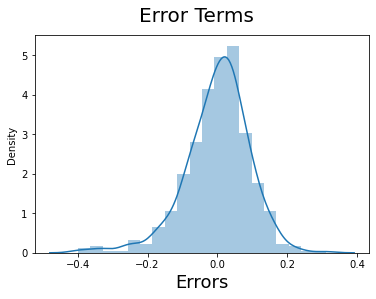

```python
res = y_train-y_train_pred
# Plot the histogram of the error terms
fig = plt.figure()
sns.distplot((res), bins = 20)
fig.suptitle('Error Terms', fontsize = 20)                  # Plot heading
plt.xlabel('Errors', fontsize = 18)
```

## Residuals are normally distributed.

# Predictions from Final Model

```python
#scaling numerica columns

num_vars = ['temp','atemp','hum','windspeed','cnt','day']

#Fit Data  - learns Min and Max , trnasform Normalises the data by applying the formulae
df_test[num_vars]=scaler.transform(df_test[num_vars])
df_test.head()
```

|  | yr | holiday | workingday | temp | atemp | hum | windspeed | cnt | day | season_spring | ... | mnth_Oct | mnth_Sept | weekday_Monday | weekday_Saturday | weekday_Sunday | weekday_Thrusday | weekday_Tuesday | weekday_Wednesday | weathersit_Bad_weathr | weathersit_Good_weathr |
| --- | --- | --- | --- | --- | --- | --- | --- | --- | --- | --- | --- | --- | --- | --- | --- | --- | --- | --- | --- | --- | --- |
| 184 | 0 | 1 | 0 | 0.831783 | 0.769660 | 0.657364 | 0.084219 | 0.692706 | 0.979592 | 0 | ... | 0 | 0 | 1 | 0 | 0 | 0 | 0 | 0 | 0 | 0 |
| 535 | 1 | 0 | 1 | 0.901354 | 0.842587 | 0.610133 | 0.153728 | 0.712034 | 0.540816 | 0 | ... | 0 | 0 | 0 | 0 | 0 | 0 | 0 | 1 | 0 | 1 |
| 299 | 0 | 0 | 1 | 0.511964 | 0.496145 | 0.837699 | 0.334206 | 0.303382 | 0.295918 | 0 | ... | 1 | 0 | 0 | 0 | 0 | 1 | 0 | 0 | 0 | 0 |
| 221 | 0 | 0 | 1 | 0.881625 | 0.795343 | 0.437098 | 0.339570 | 0.547400 | 0.285714 | 0 | ... | 0 | 0 | 0 | 0 | 0 | 0 | 0 | 1 | 0 | 1 |
| 152 | 0 | 0 | 1 | 0.817246 | 0.741471 | 0.314298 | 0.537414 | 0.569029 | 0.367347 | 0 | ... | 0 | 0 | 0 | 0 | 0 | 1 | 0 | 0 | 0 | 1 |

5 rows × 31 columns

```python
y_test = df_test.pop('cnt')
X_test = df_test
X_test.shape
```

```
(220, 30)
```

```python
#X_test_sm = sm.add_constant(X_test[X_train_sm_6.columns])
```

```python
X_train_7.columns
```

```
Index(['const', 'yr', 'temp', 'windspeed', 'season_summer', 'season_winter',
       'mnth_Sept', 'weekday_Saturday', 'weathersit_Bad_weathr',
       'weathersit_Good_weathr'],
      dtype='object')
```

```python
#to be consistent with trained model drop the colums not there
#Selecting the variables that were part of final model.
X_test_lm =sm.add_constant(X_test[[ 'yr', 'temp', 'windspeed', 'season_summer', 'season_winter',
       'mnth_Sept', 'weekday_Saturday', 'weathersit_Bad_weathr',
       'weathersit_Good_weathr']])
X_test_lm.info()
```

```
<class 'pandas.core.frame.DataFrame'>
Int64Index: 220 entries, 184 to 653
Data columns (total 10 columns):
 #   Column                  Non-Null Count  Dtype
---  ------                  --------------  -----
 0   const                   220 non-null    float64
 1   yr                      220 non-null    int64
 2   temp                    220 non-null    float64
 3   windspeed               220 non-null    float64
 4   season_summer           220 non-null    uint8
 5   season_winter           220 non-null    uint8
 6   mnth_Sept               220 non-null    uint8
 7   weekday_Saturday        220 non-null    uint8
 8   weathersit_Bad_weathr   220 non-null    uint8
 9   weathersit_Good_weathr  220 non-null    uint8
dtypes: float64(3), int64(1), uint8(6)
memory usage: 9.9 KB
```

```python
y_pred = lr_model_7.predict(X_test_lm)
```

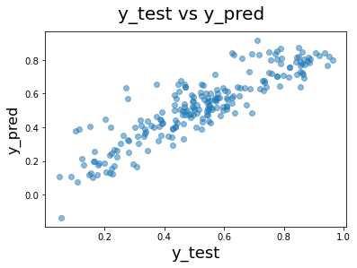

```python
# Plotting y_test and y_pred to understand the spread

fig = plt.figure()
plt.scatter(y_test, y_pred, alpha=.5)
fig.suptitle('y_test vs y_pred', fontsize = 20)              # Plot heading
plt.xlabel('y_test', fontsize = 18)                          # X-label
plt.ylabel('y_pred', fontsize = 16)
plt.show()
```